# Python Orientation

DAIS Graduate Orientation | PyData Northern Utah

Marc Dotson

# What is the benefit of learning how to code? Does it matter in the age of AI? Why Python?

[figure not shown]

- Code is transparent and reproducible
- You are responsible for your code
- Python is a general purpose, open source programming language
- “The second-best language for everything”
- Python is a *big tent*

[figure not shown]

[*Source*: Art Station](https://www.artstation.com/artwork/oAAbxL)

- Code is transparent and reproducible
- You are responsible for your code
- Python is a general purpose, open source programming language
- “The second-best language for everything”
- Python is a *big tent*

# Follow your course instructions

# Code Editors

[figure not shown]

[figure not shown]

[figure not shown]

[figure not shown]

[figure not shown]

[figure not shown]

- Code editors (i.e., IDEs) are an essential tool in the modern tech stack
- VS Code (and its *forks* like Cursor and Positron) are the industry standards
- Extensible, including GitHub integration and SSH tools/Colab GPU access
- Heavy use of the Command Palatte (Cmd/Ctrl+Shift+P)

# Python Environments

[figure not shown]

## Managing your Python environment

A Python environment is composed of the **Python version** and **library versions** (including dependencies)

```python
import polars as pl
from plotnine import *
from pyhere import here

# Load data.
customer_data = pl.read_csv(here('data', 'customer_data.csv'))
store_transactions = pl.read_csv(here('data', 'store_transactions.csv'))

# Visualize customers by region.
(ggplot(customer_data, aes(x = 'region'))
  + geom_bar()
)

# Number of customers by region.
(customer_data
  .group_by(pl.col('region'))
  .agg(n = pl.len())
)
```

## Managing your Python environment

A Python environment is composed of the **Python version** and **library versions** (including dependencies) and it is not uncommon for different projects to require **different Python versions** and **different library versions**

- A **virtual environment** (a.k.a., a **project environment**) is a self-contained, project-specific environment
- Project environments can be **reproduced on another machine** by you (including future you) or someone else
- If you need to reproduce something about your machine beyond your code, Python version, and library versions, you’ll want to use a **container**

This is part of the reason why in some courses you’ll use a **cloud-based solution** (e.g., Google Colab) where the Python environment is managed for you

[figure not shown]

- uv has rapidly emerged as the industry standard for managing Python environments
- A single tool to replace conda, pip, poetry, pyenv, virtualenv, etc.
- Installable via the command line (i.e., the programming interface into your OS itself)
- Integrated with Positron to bootstrap Python installation and environment management

# Python Scripts and Notebooks

[figure not shown]

[figure not shown]

[figure not shown]

[figure not shown]

[figure not shown]

[figure not shown]

- Notebooks combine code and writing, perfect for documenting a process and creating reports
- Jupyter notebooks don’t play well with GitHub while Marimo and Quarto do
- Quarto notebooks can be rendered into PDFs, Word documents, presentation slides, etc.

[figure not shown]

[figure not shown]

# Version Control

[figure not shown]

- GitHub hosts version-controlled project repositories managed with Git
- It is the industry standard for software development and data projects
- Using GitHub enables collaboration and the creation of a portfolio of work

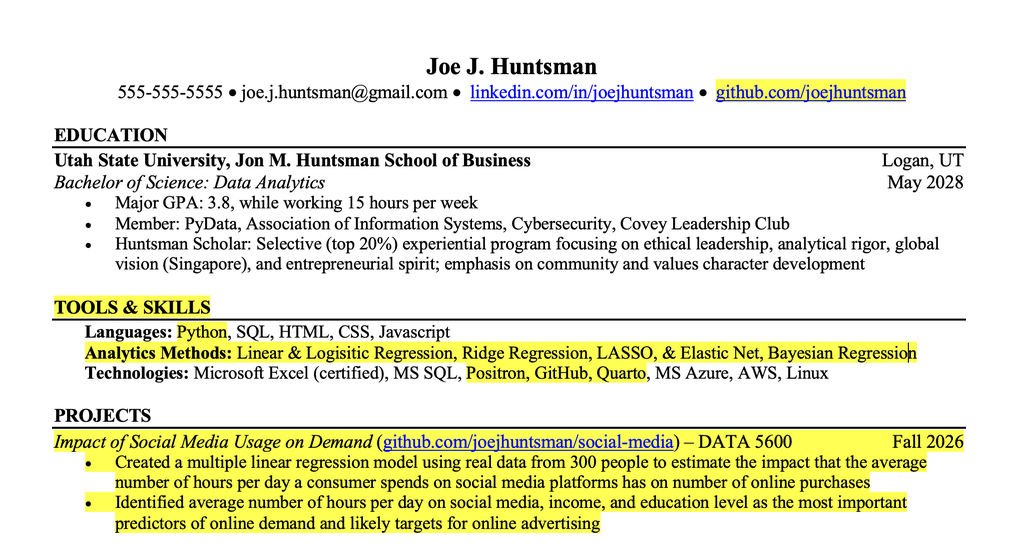

# Miscellaneous

## Concluding thoughts

Code is transparent and reproducible, but Python is a *big tent* so follow your course instructions

- Coding for a custom analysis vs. coding for production
- Code is interactive—leverage it to confirm what you’re learning
- AI can accelerate productivity, but it can’t replace learning
- You have human help—professors, peers, TAs, the ASC, etc.

Any other professorial recommendations to add?

# Questions?

[figure not shown]

- Club and professional forum to learn/retool
- Global network of chapters
- Workshops vary from beginning to advanced
- Polyglot (Python, Julia, R, etc.)

[figure not shown]

- Club and professional forum to learn/retool
- Global network of chapters
- Workshops vary from beginning to advanced
- Polyglot (Python, Julia, R, etc.)